# Homework 1

# Import Libraries

```r
library("rstudioapi")
library("ggplot2")
library(caret)
library(MASS)
library(ROCR)
library(ISLR)
library(rpart)
library(rpart.plot)
theme_set(theme_minimal())
```

# Exercise 1

```r
train_df = read.table("Data/datasimul1_train.txt",header=T)
test_df = read.table("Data/datasimul1_test.txt",header=T)

# Utility Function
mse_calculator = function(train = train_df, test = test_df, degree_range = 1:10, display_plot = FALSE, question_num = "",include_test = FALSE){
  if (include_test == FALSE){
    perf_df = data.frame(matrix(ncol = 2, nrow = 0))
    colnames(perf_df) = c("degree","mse_train")
  }else{
    perf_df = data.frame(matrix(ncol = 3, nrow = 0))
    colnames(perf_df) = c("degree","mse_train","mse_test")
  }
  for (degree in degree_range){
    model = lm(y ~ poly(x,degree), data = train)
    lm_summary = summary(model)
    mse_train = mean(lm_summary$residuals^2)
    if (include_test == TRUE){
      mse_test = mean((test$y - predict.lm(model, test)) ^ 2)
      perf_df[nrow(perf_df) + 1,] = c(degree,mse_train,mse_test)
    }else{
      perf_df[nrow(perf_df) + 1,] = c(degree,mse_train)
    }

  }
  if (display_plot == TRUE) {
    p = ggplot(perf_df, aes(x=degree)) +
      geom_line(aes(y = mse_train), color = "darkred") +
      geom_line(aes(y = mse_test), color="steelblue", linetype="twodash")
    print(p)
  }

  #knitr::kable(perf_df, format = "markdown")
  description = paste("The Result for Question: ",question_num)
  print(description)
  print(perf_df)
  return(perf_df)
}
```

## Question 1.1

```r
mse_calculator(train = train_df, test = test_df, degree_range = 1:10, display_plot = FALSE, question_num = "1.1",include_test = FALSE)
```

```
[1] "The Result for Question:  1.1"
```

|  | degree | mse_train |
| --- | --- | --- |
| 1 | 1 | 3674.203 |
| 2 | 2 | 2879.237 |
| 3 | 3 | 2620.048 |
| 4 | 4 | 2581.696 |
| 5 | 5 | 2580.861 |
| 6 | 6 | 2577.599 |
| 7 | 7 | 2577.490 |
| 8 | 8 | 2531.000 |
| 9 | 9 | 2527.848 |
| 10 | 10 | 2519.136 |

|  | degree | mse_train |
| --- | --- | --- |
| 1 | 1 | 3674.203 |
| 2 | 2 | 2879.237 |
| 3 | 3 | 2620.048 |
| 4 | 4 | 2581.696 |
| 5 | 5 | 2580.861 |
| 6 | 6 | 2577.599 |
| 7 | 7 | 2577.490 |
| 8 | 8 | 2531.000 |
| 9 | 9 | 2527.848 |
| 10 | 10 | 2519.136 |

## Question 1.2

```r
mse_calculator(train = train_df, test = test_df, degree_range = 1:10, display_plot = FALSE, question_num = "1.2",include_test = TRUE)
```

```
[1] "The Result for Question:  1.2"
```

|  | degree | mse_train | mse_test |
| --- | --- | --- | --- |
| 1 | 1 | 3674.203 | 3191.293 |
| 2 | 2 | 2879.237 | 3132.670 |
| 3 | 3 | 2620.048 | 2697.404 |
| 4 | 4 | 2581.696 | 2766.678 |
| 5 | 5 | 2580.861 | 2771.052 |
| 6 | 6 | 2577.599 | 2779.658 |
| 7 | 7 | 2577.490 | 2780.210 |
| 8 | 8 | 2531.000 | 2797.354 |
| 9 | 9 | 2527.848 | 2811.074 |
| 10 | 10 | 2519.136 | 2848.809 |

|  | degree | mse_train | mse_test |
| --- | --- | --- | --- |
| 1 | 1 | 3674.203 | 3191.293 |
| 2 | 2 | 2879.237 | 3132.670 |
| 3 | 3 | 2620.048 | 2697.404 |
| 4 | 4 | 2581.696 | 2766.678 |
| 5 | 5 | 2580.861 | 2771.052 |
| 6 | 6 | 2577.599 | 2779.658 |
| 7 | 7 | 2577.490 | 2780.210 |
| 8 | 8 | 2531.000 | 2797.354 |
| 9 | 9 | 2527.848 | 2811.074 |
| 10 | 10 | 2519.136 | 2848.809 |

## Question 1.3

```
[1] "The Result for Question:  1.3"
```

|  | degree | mse_train | mse_test |
| --- | --- | --- | --- |
| 1 | 1 | 3674.203 | 3191.293 |
| 2 | 2 | 2879.237 | 3132.670 |
| 3 | 3 | 2620.048 | 2697.404 |
| 4 | 4 | 2581.696 | 2766.678 |
| 5 | 5 | 2580.861 | 2771.052 |
| 6 | 6 | 2577.599 | 2779.658 |
| 7 | 7 | 2577.490 | 2780.210 |
| 8 | 8 | 2531.000 | 2797.354 |
| 9 | 9 | 2527.848 | 2811.074 |
| 10 | 10 | 2519.136 | 2848.809 |

|  | degree | mse_train | mse_test |
| --- | --- | --- | --- |
| 1 | 1 | 3674.203 | 3191.293 |
| 2 | 2 | 2879.237 | 3132.670 |
| 3 | 3 | 2620.048 | 2697.404 |
| 4 | 4 | 2581.696 | 2766.678 |
| 5 | 5 | 2580.861 | 2771.052 |
| 6 | 6 | 2577.599 | 2779.658 |
| 7 | 7 | 2577.490 | 2780.210 |
| 8 | 8 | 2531.000 | 2797.354 |
| 9 | 9 | 2527.848 | 2811.074 |
| 10 | 10 | 2519.136 | 2848.809 |

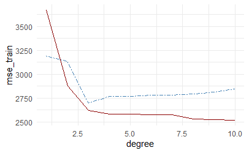

```r
mse_calculator(train = train_df, test = test_df, degree_range = 1:10, display_plot = TRUE, question_num = "1.3",include_test = TRUE)
```

## Question 1.4

```
[1] "The Result for Question:  1.4"
```

|  | degree | mse_train | mse_test |
| --- | --- | --- | --- |
| 1 | 10 | 2519.136 | 2848.809 |
| 2 | 9 | 2527.848 | 2811.074 |
| 3 | 8 | 2531.000 | 2797.354 |
| 4 | 7 | 2577.490 | 2780.210 |
| 5 | 6 | 2577.599 | 2779.658 |
| 6 | 5 | 2580.861 | 2771.052 |
| 7 | 4 | 2581.696 | 2766.678 |
| 8 | 3 | 2620.048 | 2697.404 |
| 9 | 2 | 2879.237 | 3132.670 |
| 10 | 1 | 3674.203 | 3191.293 |

|  | degree | mse_train | mse_test |
| --- | --- | --- | --- |
| 1 | 10 | 2519.136 | 2848.809 |
| 2 | 9 | 2527.848 | 2811.074 |
| 3 | 8 | 2531.000 | 2797.354 |
| 4 | 7 | 2577.490 | 2780.210 |
| 5 | 6 | 2577.599 | 2779.658 |
| 6 | 5 | 2580.861 | 2771.052 |
| 7 | 4 | 2581.696 | 2766.678 |
| 8 | 3 | 2620.048 | 2697.404 |
| 9 | 2 | 2879.237 | 3132.670 |
| 10 | 1 | 3674.203 | 3191.293 |

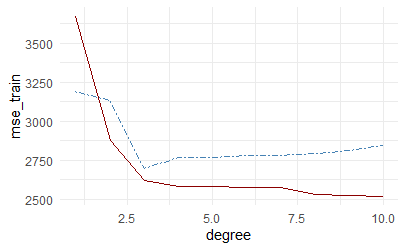

```r
mse_calculator(train = train_df, test = test_df, degree_range = 10:1, display_plot = TRUE, question_num = "1.4",include_test = TRUE)
```

## Question 1.5

From the result of this question, one can notice that the MSE is higher on the test set than on the training set with a test set MSE of 0.07 and a train set MSE of 0.067 which is due to the model having learned the estimates for the training set and not the test set.

```r
mydata=read.csv("Data/kc_house_data.csv")
mydata$log_price=log(mydata$price)
mydata$bedrooms2=mydata$bedroom^2
mydata$log_sqft_living=log(mydata$sqft_living)
mydata$log_sqft_lot=log(mydata$sqft_lot)
mydata$floors_cat=as.factor(mydata$floors)
mydata$condition_binaire=ifelse(mydata$condition>=3,1,0)
mydata$log_sqft_above=log(mydata$sqft_above)
mydata$age=2015-mydata$yr_built
mydata$age2=mydata$age^2
mydata$lat2=mydata$lat^2
mydata$long2=mydata$long^2
mydata$lat3=mydata$lat^3
mydata$long3=mydata$long^3

# Division de l'échantillon (train = 10,000 observations)
set.seed(200)
n=nrow(mydata)
id.train=sample(1:n,10000,replace=FALSE)
id.valid=sample(setdiff(1:n,id.train),11613,replace=FALSE)

# Division de l'échantillon
mydata.train=mydata[id.train,]
mydata.valid=mydata[id.valid,]
model1=lm(log_price~bedrooms+bathrooms+log_sqft_living+log_sqft_lot+floors_cat
          +waterfront+condition_binaire+grade+log_sqft_above+sqft_basement
          +age+lat+long,data=mydata.train)
model1_summary = summary(model1)
mse_train_model1 = mean(model1_summary$residuals^2)
mse_test1 = mean((mydata.valid$log_price - predict.lm(model1, mydata.valid)) ^ 2)
print(mse_test1)
```

```
[1] 0.07046677
```

```r
print(mse_train_model1)
```

```
[1] 0.06708955
```

# Exercise 2

## Question 2.1

The **misclassification rate** measures the percentage of all the observations that were wrongly predicted meaning the observation reoffended when predicted not to and vice versa.

The difference between the false positive rate and the false discovery rate is the denominator and depends on how you want to represent the false positive.

The **false negative rate** measures the number of observations that were predicted as were not going to reoffend but in fact did reoffend as a percentage of observations that did reoffend.

## Question 2.2

```r
compas_df = read.csv("Data/Compas.csv", sep=";",header=T)
compas_df$decil_score
```

```r
compas_df$two_year_recid
```

```
   [1] 0 1 1 0 0 0 1 0 0 1 0 1 0 0 1 1
  [17] 0 0 1 1 1 1 1 0 1 0 0 1 0 1 1 1
  [33] 1 0 1 0 1 1 1 0 0 0 1 0 1 1 1 0
  [49] 1 0 1 0 1 0 0 1 0 0 0 0 1 1 1 1
  [65] 1 1 0 1 0 0 1 0 0 1 1 0 1 0 1 1
  [81] 0 0 1 1 1 1 1 1 0 1 1 1 1 0 0 1
  [97] 0 0 0 1 0 0 1 1 0 0 0 1 0 1 1 0
 [113] 1 0 1 1 1 1 0 0 1 1 0 0 1 0 1 0
 [129] 0 0 0 0 1 0 1 1 1 1 1 0 1 0 0 0
 [145] 1 1 1 1 1 1 0 0 1 1 0 1 0 0 1 0
 [161] 0 1 0 0 0 1 0 0 1 0 0 0 0 0 0 1
 [177] 1 0 0 1 0 0 1 1 1 1 0 1 0 1 1 1
 [193] 1 1 1 0 1 0 0 1 0 0 0 1 1 1 0 0
 [209] 1 1 0 0 0 1 0 0 0 0 0 1 0 1 0 1
 [225] 0 0 1 0 1 0 0 1 0 0 1 0 0 1 0 0
```

[output cut: 49 more lines]

```r
compas_df$recidive_pred = factor(ifelse(compas_df$decile_score>=6, 1, 0))

conf_matrix = confusionMatrix(data=factor(compas_df$recidive_pred), reference = factor(compas_df$two_year_recid))
fp = conf_matrix$table[2,1]
tp = conf_matrix$table[2,2]
tn = conf_matrix$table[1,1]
fn = conf_matrix$table[1,2]

#Question 2.2
# misclassification
mis_rate = (fp + fn)/(fp + fn + tn +tp)
# false positive rate
fpr = fp / (fp + tn)
# false discovery rates
fdr = fp / (fp + tp)
print(mis_rate)
```

```
[1] 0.3422512
```

```r
print(fpr)
```

```
[1] 0.2339137
```

```r
print(fdr)
```

```
[1] 0.3516692
```

## Question 2.3

```r
compas_df$decile_score_scaled = compas_df$decile_score / 10
compas_df$decile_score_scaled
```

```
   [1] 0.1 0.3 0.4 0.8 0.1 0.1 0.6 0.4
   [9] 0.1 0.3 0.4 0.6 0.1 0.4 0.1 0.3
  [17] 0.1 1.0 0.5 0.3 0.6 0.9 0.2 0.4
  [25] 0.4 0.1 0.3 0.3 0.3 0.7 1.0 0.9
  [33] 0.8 0.1 0.3 0.8 0.5 0.2 0.9 0.2
  [41] 0.8 0.1 0.2 0.2 0.7 1.0 0.8 0.1
  [49] 0.3 0.4 0.2 0.2 0.6 0.1 0.5 0.4
  [57] 0.7 0.1 0.5 0.3 0.7 1.0 0.2 0.4
  [65] 1.0 0.9 0.1 0.6 0.1 0.1 0.1 0.4
  [73] 0.4 0.6 0.6 0.2 0.3 0.8 0.4 0.7
  [81] 0.2 0.2 1.0 0.1 1.0 0.5 0.9 0.7
  [89] 0.2 0.7 0.8 0.6 0.8 0.7 0.7 0.1
  [97] 0.1 0.1 0.1 0.4 0.2 0.2 0.1 0.6
 [105] 0.4 0.5 0.4 0.9 0.1 0.9 0.4 0.5
 [113] 0.5 0.2 0.2 0.9 0.4 0.8 0.7 0.2
```

[output cut: 111 more lines]

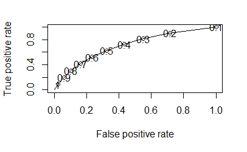

```r
pred = prediction(compas_df$decile_score_scaled,compas_df$two_year_recid)
perf <- performance(pred, "tpr", "fpr")
cost_perf <- performance(pred, "cost")
plot(perf,print.cutoffs.at=seq(0.1,by=0.1))
```

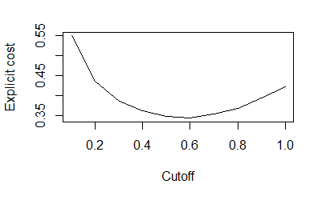

```r
plot(cost_perf)
```

```r
pred@cutoffs[[1]][which.min(cost_perf@y.values[[1]])]
```

```
[1] 0.6
```

## Question 2.4

```r
afr_amer_df = subset(compas_df,race == 'African-American')
conf_matrix_afr = confusionMatrix(data=factor(afr_amer_df$recidive_pred), reference = factor(afr_amer_df$two_year_recid))
fp_afr = conf_matrix_afr$table[2,1]
tp_afr = conf_matrix_afr$table[2,2]
tn_afr = conf_matrix_afr$table[1,1]
fn_afr = conf_matrix_afr$table[1,2]
print('African-American')
```

```
[1] "African-American"
```

```r
# misclassification
mis_rate_afr = (fp_afr + fn_afr)/(fp_afr + fn_afr + tn_afr + tp_afr)
# false positive rate
fpr_afr = fp_afr / (fp_afr + tn_afr)
# false discovery rates
fdr_afr = fp_afr / (fp_afr + tp_afr)

print(mis_rate_afr)
```

```
[1] 0.3582251
```

```r
print(fpr_afr)
```

```
[1] 0.3431755
```

```r
print(fdr_afr)
```

```
[1] 0.3405196
```

```r
cauc_df = subset(compas_df,race == 'Caucasian')
conf_matrix_cauc = confusionMatrix(data=factor(cauc_df$recidive_pred), reference = factor(cauc_df$two_year_recid))
fp_cauc = conf_matrix_cauc$table[2,1]
tp_cauc = conf_matrix_cauc$table[2,2]
tn_cauc = conf_matrix_cauc$table[1,1]
fn_cauc = conf_matrix_cauc$table[1,2]

# misclassification
mis_rate_cauc = (fp_cauc + fn_cauc)/(fp_cauc + fn_cauc + tn_cauc + tp_cauc)
# false positive rate
fpr_cauc = fp_cauc / (fp_cauc + tn_cauc)
# false discovery rates
fdr_cauc = fp_cauc / (fp_cauc + tp_cauc)
print('Caucasian')
```

```
[1] "Caucasian"
```

```r
print(mis_rate_cauc)
```

```
[1] 0.3223309
```

```r
print(fpr_cauc)
```

```
[1] 0.1471774
```

```r
print(fdr_cauc)
```

```
[1] 0.3572594
```

## Question 2.5

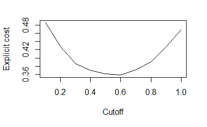

```r
pred_afr_amer = prediction(afr_amer_df$decile_score_scaled,afr_amer_df$two_year_recid)
cost_perf_afr_amer <- performance(pred_afr_amer, "cost")
plot(cost_perf_afr_amer)
```

```r
pred_afr_amer@cutoffs[[1]][which.min(cost_perf_afr_amer@y.values[[1]])]
```

```
[1] 0.6
```

## Question 2.5

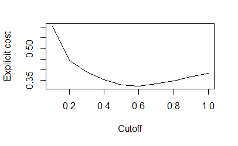

```r
pred_cauc = prediction(cauc_df$decile_score_scaled,cauc_df$two_year_recid)
cost_perf_cauc <- performance(pred_cauc, "cost")
plot(cost_perf_cauc)
```

```r
pred_afr_cauc@cutoffs[[1]][which.min(cost_perf_cauc@y.values[[1]])]
```

```
[1] 0.6
```

## Question 2.5

The cutoff point has remained stayed the same for me, but when looking at the cutoff graph, we can notice a much greater in terms of the acceleration of the cost for African Americans than Caucasian meaning that it is easy to misclassify the african american population.

## Question 2.6

The purpose of this exercise was to assess the power that algorithms can have on decisions pertaining to real people, with bias being observed to the african american population.

# Exercise 3

```r
dbm_df = read.csv("Data/dbm_final.csv",header=T)
dbm_df$region=as.factor(dbm_df$region)
dbm_df$revenu=as.factor(dbm_df$revenu)
model_dbm=glm(yachat~sexe + age + revenu + region + conjoint + anneeclient + semainedernier+montantdernier + montantunan + achatunan,family="binomial",data=dbm_df[dbm_df$train==1,] )
summary(model_dbm)
```

```
Call:
glm(formula = yachat ~ sexe + age + revenu + region + conjoint +
    anneeclient + semainedernier + montantdernier + montantunan +
    achatunan, family = "binomial", data = dbm_df[dbm_df$train ==
    1, ])

Deviance Residuals:
     Min        1Q    Median
-2.64337  -0.54183  -0.26502
      3Q       Max
-0.06633   2.62366

Coefficients:
                Estimate Std. Error
(Intercept)     2.953849   0.651620
sexe            0.886334   0.239646
age            -0.153695   0.016122
revenu2        -0.731207   0.253538
revenu3        -0.206184   0.298164
region2         0.111282   0.330403
region3         0.602417   0.313190
region4         0.662268   0.324184
region5         0.001325   0.357329
conjoint       -0.940776   0.249413
anneeclient     0.009895   0.034270
semainedernier  0.053681   0.010310
montantdernier  0.345995   0.038538
montantunan     0.002223   0.002398
achatunan      -0.125446   0.023850
               z value Pr(>|z|)
(Intercept)      4.533 5.81e-06 ***
sexe             3.699 0.000217 ***
age             -9.533  < 2e-16 ***
revenu2         -2.884 0.003926 **
revenu3         -0.692 0.489244
region2          0.337 0.736263
region3          1.923 0.054419 .
region4          2.043 0.041065 *
region5          0.004 0.997041
conjoint        -3.772 0.000162 ***
anneeclient      0.289 0.772780
semainedernier   5.207 1.92e-07 ***
montantdernier   8.978  < 2e-16 ***
montantunan      0.927 0.353978
achatunan       -5.260 1.44e-07 ***
---
Signif. codes:
  0 ‘***’ 0.001 ‘**’ 0.01 ‘*’ 0.05
  ‘.’ 0.1 ‘ ’ 1

(Dispersion parameter for binomial family taken to be 1)

    Null deviance: 1027.91  on 999  degrees of freedom
Residual deviance:  663.18  on 985  degrees of freedom
AIC: 693.18

Number of Fisher Scoring iterations: 6
```

```r
y_true = dbm_df$yachat
y_pred = predict(model_dbm, dbm_df, type="response")

min(y_pred)
```

```
[1] 2.20045e-05
```

```r
max(y_pred)
```

```
[1] 0.9999202
```

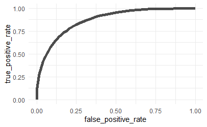

```r
plot_roc = function(y_true,y_pred,increment = 0.02){
  perf_df = data.frame(matrix(ncol = 3, nrow = 0))
  colnames(perf_df) = c("threshold","true_positive_rate","false_positive_rate")
  for(i in seq(from=0, to=1, by=increment)){
    y_temp_pred = ifelse(y_pred>=i,1,0)
    conf_matrix = confusionMatrix(data=factor(y_temp_pred), reference = factor(y_true))
    fp = conf_matrix$table[2,1]
    tp = conf_matrix$table[2,2]
    tn = conf_matrix$table[1,1]
    fn = conf_matrix$table[1,2]
    #sensitivity_temp = tp/(tp+fn)
    #specificity_temp = tn/(tn+fp)
    fpr = fp / (fp + tn)
    tpr = tp/(tp+fn)
    perf_df[nrow(perf_df) + 1,] = c(i,tpr,fpr)
  }
  #p = (ggplot(data = perf_df,aes(x=fpr,y=tpr,group = 1)) +
  #  geom_line())
  p = ggplot(perf_df,aes(false_positive_rate,true_positive_rate))+geom_line(size = 2, alpha = 0.7)
  print(p)
  return(perf_df)
}
df2 = plot_roc(y_true,y_pred)
```

## Question 4.1a

The age coefficient displays that an increase in age of a year on average leads to a log likelihood increase of purchase of 0.075.

```r
rodeo_df = read.csv("Data/rodeo.csv",header=T)
model_rodeo=glm(achat~age,family="binomial",data=rodeo_df )
# Question 4.1 a
summary(model_rodeo)
```

```
Call:
glm(formula = achat ~ age, family = "binomial", data = rodeo_df)

Deviance Residuals:
    Min       1Q   Median       3Q
-1.6173  -1.0610  -0.8073   1.1692
    Max
 1.9010

Coefficients:
            Estimate Std. Error
(Intercept) -3.04989    0.57449
age          0.07486    0.01473
            z value Pr(>|z|)
(Intercept)  -5.309 1.10e-07 ***
age           5.081 3.76e-07 ***
---
Signif. codes:
  0 ‘***’ 0.001 ‘**’ 0.01 ‘*’ 0.05
  ‘.’ 0.1 ‘ ’ 1

(Dispersion parameter for binomial family taken to be 1)

    Null deviance: 689.27  on 499  degrees of freedom
Residual deviance: 661.40  on 498  degrees of freedom
AIC: 665.4

Number of Fisher Scoring iterations: 4
```

## Question 4.1b

```r
predict(model_rodeo, data.frame(age = c(35)), type="response")
```

```
        1
0.3941779
```

```r
predict(model_rodeo, data.frame(age = c(50)), type="response")
```

```
        1
0.6666599
```

## Question 4.1c

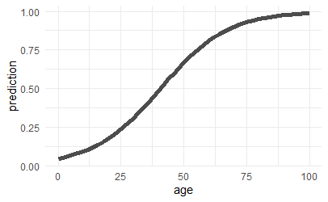

```r
age_pred_df = data.frame(matrix(ncol = 2, nrow = 0))
colnames(age_pred_df) = c("age","prediction")

for(year in seq(from=0, to=100, by=2)){
  prediction_age = predict(model_rodeo, data.frame(age = c(year)), type="response")
  age_pred_df[nrow(age_pred_df) + 1,] = c(year,prediction_age)
}
p = ggplot(age_pred_df,aes(age,prediction))+geom_line(size = 2, alpha = 0.7)
print(p)
```

## Question 4.1d

```r
set.seed(101)
sample <- sample.int(n = nrow(rodeo_df), size = floor(.75*nrow(rodeo_df)), replace = F)
train_rod_df <- rodeo_df[sample, ]
test_rod_df  <- rodeo_df[-sample, ]

ctrl <- trainControl(method = "cv", number = 5)

rodeo_df$achat = factor(rodeo_df$achat)

model_rodeo_cv <- train(achat~age, data = rodeo_df, method = "glm", trControl = ctrl,family=binomial())
print(summary(model_rodeo_cv))
```

```
Call:
NULL

Deviance Residuals:
    Min       1Q   Median       3Q
-1.6173  -1.0610  -0.8073   1.1692
    Max
 1.9010

Coefficients:
            Estimate Std. Error
(Intercept) -3.04989    0.57449
age          0.07486    0.01473
            z value Pr(>|z|)
(Intercept)  -5.309 1.10e-07 ***
age           5.081 3.76e-07 ***
---
Signif. codes:
  0 ‘***’ 0.001 ‘**’ 0.01 ‘*’ 0.05
  ‘.’ 0.1 ‘ ’ 1

(Dispersion parameter for binomial family taken to be 1)

    Null deviance: 689.27  on 499  degrees of freedom
Residual deviance: 661.40  on 498  degrees of freedom
AIC: 665.4

Number of Fisher Scoring iterations: 4
```

```r
#model_rodeo_cv=glm(achat~age,family="binomial",data=train_rod_df )
y_pred_rod_cv = predict(model_rodeo_cv, test_rod_df, type="raw")


conf_matrix_rod_cv = confusionMatrix(data=factor(y_pred_rod_cv), reference = factor(test_rod_df$achat))
fp_rod_cv = conf_matrix_rod_cv$table[2,1]
tp_rod_cv = conf_matrix_rod_cv$table[2,2]
tn_rod_cv = conf_matrix_rod_cv$table[1,1]
fn_rod_cv = conf_matrix_rod_cv$table[1,2]
fpr_rod_cv = fp_rod_cv / (fp_rod_cv + tn_rod_cv)

print(fpr_rod_cv)
```

```
[1] 0.3333333
```

```r
set.seed(200)
n=nrow(rodeo_df)
id.train=sample(1:n,300,replace=FALSE)
id.valid=sample(setdiff(1:n,id.train),100,replace=FALSE)
id.test=setdiff(setdiff(1:n,id.train),id.valid)

# Division de l'échantillon
rodeo_df.train=rodeo_df[id.train,]
rodeo_df.valid=rodeo_df[id.valid,]
rodeo_df.test=rodeo_df[id.test,]
```

# Question 4.3a

An increase in revenue by 1 unit reduces the log likelihood of purchase by 0.85

```r
model_rodeo_all_var=glm(achat~.,family="binomial",data=rodeo_df.train )
summary(model_rodeo_all_var)
```

```
Call:
glm(formula = achat ~ ., family = "binomial", data = rodeo_df.train)

Deviance Residuals:
    Min       1Q   Median       3Q
-2.7104  -0.8493  -0.2500   0.8283
    Max
 2.4379

Coefficients:
            Estimate Std. Error
(Intercept) -0.13555    1.17238
emploi       0.05357    0.12338
revenu      -0.85884    0.15719
sexe         1.51398    0.34115
univ         2.17665    0.40756
age          0.09944    0.02513
rodeo       -1.36686    0.24239
            z value Pr(>|z|)
(Intercept)  -0.116    0.908
emploi        0.434    0.664
revenu       -5.464 4.66e-08 ***
sexe          4.438 9.09e-06 ***
univ          5.341 9.26e-08 ***
age           3.957 7.59e-05 ***
rodeo        -5.639 1.71e-08 ***
---
Signif. codes:
  0 ‘***’ 0.001 ‘**’ 0.01 ‘*’ 0.05
  ‘.’ 0.1 ‘ ’ 1

(Dispersion parameter for binomial family taken to be 1)

    Null deviance: 414.81  on 299  degrees of freedom
Residual deviance: 298.46  on 293  degrees of freedom
AIC: 312.46

Number of Fisher Scoring iterations: 5
```

## Question 4.3 b

76% of the time, the model is capable of predicting a purchase given that there was a purchase (sensitivity)

63% of the time the model is capable of accurately predicting that an observation did not complete the purchase given that they did not complete the purchase.

```r
y_pred_all_var_prob = predict(model_rodeo_all_var, rodeo_df.valid, type="response")
y_pred_all_var = ifelse(y_pred_all_var_prob>=0.5,1,0)
conf_matrix_all_var = confusionMatrix(data=factor(y_pred_all_var), reference = factor(rodeo_df.valid$achat))
fp_all_var = conf_matrix_all_var$table[2,1]
tp_all_var = conf_matrix_all_var$table[2,2]
tn_all_var = conf_matrix_all_var$table[1,1]
fn_all_var = conf_matrix_all_var$table[1,2]
sensitivity_all_var = tp_all_var/(tp_all_var+fn_all_var)
specificity_all_var = tn_all_var/(tn_all_var+fp_all_var)
print(sensitivity_all_var)
```

```
[1] 0.7674419
```

```r
print(specificity_all_var)
```

```
[1] 0.6315789
```

## Question 4.3 c

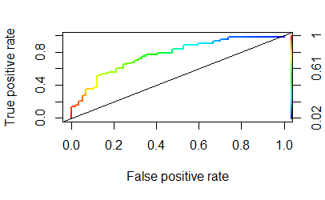

```r
pred_all_var = prediction(y_pred_all_var_prob,rodeo_df.valid$achat)
perf_sn_sp = performance(pred_all_var, "tpr","fpr")
plot(perf_sn_sp,colorize = T, lwd = 2)
abline(a = 0, b = 1)
```

```r
auc = performance(pred_all_var, measure = "auc")
print(auc@y.values)
```

```
[[1]]
[1] 0.7631579
```

## Question 4.4

Looking at the next 2 cells AIC and BIC are lower when including all the variables than when looking only at age interactions. This is because the BIC penalizes more when you have more features. But then when comparing the misclassification rate, they are both the same performancewise so more complexity does not improve the model.

```r
model_rodeo_interactions=glm(achat~(.)*age,family="binomial",data=rodeo_df.train )
summary(model_rodeo_interactions)
```

```
Call:
glm(formula = achat ~ (.) * age, family = "binomial", data = rodeo_df.train)

Deviance Residuals:
    Min       1Q   Median       3Q
-2.6918  -0.8020  -0.2239   0.8187
    Max
 2.4746

Coefficients:
            Estimate Std. Error
(Intercept) -4.85648    5.51929
emploi       0.37496    0.80791
revenu      -2.45980    1.06567
sexe         3.56560    2.33634
univ         1.13420    2.81687
age          0.23094    0.14500
rodeo        1.73678    1.69083
emploi:age  -0.00887    0.02107
revenu:age   0.03993    0.02686
sexe:age    -0.05228    0.05884
univ:age     0.02804    0.07005
age:rodeo   -0.08245    0.04486
            z value Pr(>|z|)
(Intercept)  -0.880    0.379
emploi        0.464    0.643
revenu       -2.308    0.021 *
sexe          1.526    0.127
univ          0.403    0.687
age           1.593    0.111
rodeo         1.027    0.304
emploi:age   -0.421    0.674
revenu:age    1.487    0.137
sexe:age     -0.888    0.374
univ:age      0.400    0.689
age:rodeo    -1.838    0.066 .
---
Signif. codes:
  0 ‘***’ 0.001 ‘**’ 0.01 ‘*’ 0.05
  ‘.’ 0.1 ‘ ’ 1

(Dispersion parameter for binomial family taken to be 1)

    Null deviance: 414.81  on 299  degrees of freedom
Residual deviance: 288.53  on 288  degrees of freedom
AIC: 312.53

Number of Fisher Scoring iterations: 5
```

```r
y_pred_interactions = ifelse(predict(model_rodeo_interactions, rodeo_df.valid, type="response")>=0.5,1,0)
y_pred_interactions_prob = predict(model_rodeo_interactions, rodeo_df.valid, type="response")

print(AIC(model_rodeo_interactions))
```

```
[1] 312.528
```

```r
print(BIC(model_rodeo_interactions))
```

```
[1] 356.9734
```

```r
conf_matrix_interactions = confusionMatrix(data=factor(y_pred_interactions), reference = factor(rodeo_df.valid$achat))
fp_interactions = conf_matrix_interactions$table[2,1]
tp_interactions = conf_matrix_interactions$table[2,2]
tn_interactions = conf_matrix_interactions$table[1,1]
fn_interactions = conf_matrix_interactions$table[1,2]

pred_interactions = prediction(y_pred_interactions_prob,rodeo_df.valid$achat)

auc_interactions = performance(pred_interactions, measure = "auc")
print(auc_interactions@y.values)
```

```
[[1]]
[1] 0.7407181
```

```r
# misclassification
mis_rate_interactions = (fp_interactions + fn_interactions)/(fp_interactions + fn_interactions + tn_interactions +tp_interactions)
print(mis_rate_interactions)
```

```
[1] 0.31
```

```r
print(AIC(model_rodeo_all_var))
```

```
[1] 312.4596
```

```r
print(BIC(model_rodeo_all_var))
```

```
[1] 338.3861
```

```r
conf_matrix_all_var = confusionMatrix(data=factor(y_pred_all_var), reference = factor(rodeo_df.valid$achat))
fp_all_var = conf_matrix_all_var$table[2,1]
tp_all_var = conf_matrix_all_var$table[2,2]
tn_all_var = conf_matrix_all_var$table[1,1]
fn_all_var = conf_matrix_all_var$table[1,2]

# misclassification
mis_rate_all_var = (fp_all_var + fn_all_var)/(fp_all_var + fn_all_var + tn_all_var +tp_all_var)

print(mis_rate_all_var)
```

```
[1] 0.31
```

## Question 4.5

```r
sensitivity_interactions = tp_interactions/(tp_interactions+fn_interactions)
specificity_interactions = tn_interactions/(tn_interactions+fp_interactions)
print(sensitivity_interactions)
```

```
[1] 0.7674419
```

```r
print(specificity_interactions)
```

```
[1] 0.6315789
```

## Question 4.6

```r
step_wise_model_interactions <- stepAIC(model_rodeo_interactions, direction = "both",
                      trace = FALSE)
y_pred_step_wise_interactions_prob = predict(model_rodeo_interactions, rodeo_df.valid, type="response")

summary(step_wise_model_interactions)
```

```
Call:
glm(formula = achat ~ revenu + sexe + univ + age + rodeo + revenu:age +
    age:rodeo, family = "binomial", data = rodeo_df.train)

Deviance Residuals:
    Min       1Q   Median       3Q
-2.7076  -0.8181  -0.2213   0.8081
    Max
 2.4669

Coefficients:
            Estimate Std. Error
(Intercept) -1.32441    4.82687
revenu      -2.66755    1.02067
sexe         1.56896    0.34721
univ         2.21075    0.41670
age          0.14141    0.12618
rodeo        1.27696    1.52162
revenu:age   0.04564    0.02547
age:rodeo   -0.07023    0.04002
            z value Pr(>|z|)
(Intercept)  -0.274  0.78379
revenu       -2.614  0.00896 **
sexe          4.519 6.22e-06 ***
univ          5.305 1.12e-07 ***
age           1.121  0.26244
rodeo         0.839  0.40135
revenu:age    1.792  0.07317 .
age:rodeo    -1.755  0.07928 .
---
Signif. codes:
  0 ‘***’ 0.001 ‘**’ 0.01 ‘*’ 0.05
  ‘.’ 0.1 ‘ ’ 1

(Dispersion parameter for binomial family taken to be 1)

    Null deviance: 414.81  on 299  degrees of freedom
Residual deviance: 290.81  on 292  degrees of freedom
AIC: 306.81

Number of Fisher Scoring iterations: 5
```

```r
pred_step_wise_interactions = prediction(y_pred_step_wise_interactions_prob,rodeo_df.valid$achat)

auc_step_wise_interactions = performance(pred_step_wise_interactions, measure = "auc")
print(auc_step_wise_interactions@y.values)
```

```
[[1]]
[1] 0.7407181
```

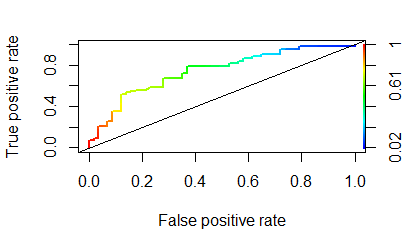

```r
perf_step_wise_interactions = performance(pred_step_wise_interactions, "tpr","fpr")
plot(perf_step_wise_interactions,colorize = T, lwd = 2)
abline(a = 0, b = 1)
```

# Exercise 5

```r
set.seed(12345)
x=rnorm(1000)
variations = c(0.1,0.5,1,1.5,2,2.5,3)
num_obs = c(10,30,50,100,200,500,1000)

beta0=1
beta1=2
sigma=1
y=beta0+beta1*x+ rlnorm(200)

#x[1:100]

#model=lm(y~x)
#summary(model)
#model$coefficients[2]


sim_df = data.frame(matrix(ncol = 3, nrow = 0))
colnames(sim_df) = c("error_variation","sample_size","b1_est")
for (var in variations){
  for (n in num_obs){
    x_sub = x[1:n]
    error_term = rnorm(n = n, sd = var)
    y = beta0 + beta1*x_sub + error_term
    model=lm(y~x_sub)
    #model_sum = summary(model)
    b1_est = model$coefficients[2]
    sim_df[nrow(sim_df) + 1,] = c(var,n,b1_est)
  }
}
standard_error = sd(sim_df$b1_est)/sqrt(length(sim_df$b1_est))
print(standard_error)
```

```
[1] 0.04229612
```

```r
sim_df_500 = data.frame(matrix(ncol = 3, nrow = 0))
colnames(sim_df_500) = c("error_variation","sample_size","b1_est")
for (i in 1:500){
  for (var in variations){
    for (n in num_obs){
      x_sub = x[1:n]
      error_term = rnorm(n = n, sd = var)
      y = beta0 + beta1*x_sub + error_term
      model=lm(y~x_sub)
      #model_sum = summary(model)
      b1_est = model$coefficients[2]
      sim_df_500[nrow(sim_df_500) + 1,] = c(var,n,b1_est)
    }
  }
}
standard_error_500 = sd(sim_df_500$b1_est)/sqrt(length(sim_df_500$b1_est))
standard_error_500
```

```
[1] 0.002148745
```

# Exercise 6

## Question 6.1

```r
n=nrow(OJ)
set.seed(1234)
id.train=sample(1:n,size=800)
id.test=setdiff(1:n,id.train)
OJ.train=OJ[id.train,-3]
OJ.test=OJ[id.test,-3]
```

## Question 6.2

[figure not shown]

```r
mytree = rpart(Purchase~., data=OJ.train, method = "class")
plot(mytree)
text(mytree)
```

```r
length(rownames(mytree$frame)[mytree$frame$var == "<leaf>"])
```

```
[1] 8
```

## Question 6.3

Node number 11: 75 observations, complexity param=0.02365931 predicted class=MM expected loss=0.4 P(node) =0.09375 class counts: 30 45 probabilities: 0.400 0.600 left son=22 (20 obs) right son=23 (55 obs) Primary splits: ListPriceDiff < 0.235 to the right, improve=4.909091, (0 missing) PriceDiff < -0.165 to the right, improve=4.100996, (0 missing) WeekofPurchase < 242 to the left, improve=3.137733, (0 missing) DiscMM < 0.47 to the left, improve=2.578947, (0 missing) PctDiscMM < 0.227263 to the left, improve=2.578947, (0 missing) Surrogate splits: PriceMM < 2.155 to the right, agree=0.760, adj=0.10, (0 split) PriceCH < 1.755 to the left, agree=0.747, adj=0.05, (0 split) SalePriceCH < 1.755 to the left, agree=0.747, adj=0.05, (0 split) PriceDiff < -0.165 to the right, agree=0.747, adj=0.05, (0 split)

```r
print(mytree)
```

```
n= 800

node), split, n, loss, yval, (yprob)
      * denotes terminal node

 1) root 800 317 CH (0.60375000 0.39625000)
   2) LoyalCH>=0.48285 498  81 CH (0.83734940 0.16265060)
     4) LoyalCH>=0.7645725 266  10 CH (0.96240602 0.03759398) *
     5) LoyalCH< 0.7645725 232  71 CH (0.69396552 0.30603448)
      10) PriceDiff>=0.015 157  26 CH (0.83439490 0.16560510) *
      11) PriceDiff< 0.015 75  30 MM (0.40000000 0.60000000)
        22) ListPriceDiff>=0.235 20   6 CH (0.70000000 0.30000000) *
        23) ListPriceDiff< 0.235 55  16 MM (0.29090909 0.70909091)
          46) STORE>=3.5 8   2 CH (0.75000000 0.25000000) *
          47) STORE< 3.5 47  10 MM (0.21276596 0.78723404) *
   3) LoyalCH< 0.48285 302  66 MM (0.21854305 0.78145695)
     6) LoyalCH>=0.2779765 129  46 MM (0.35658915 0.64341085)
      12) SpecialCH>=0.5 17   5 CH (0.70588235 0.29411765) *
      13) SpecialCH< 0.5 112  34 MM (0.30357143 0.69642857) *
     7) LoyalCH< 0.2779765 173  20 MM (0.11560694 0.88439306) *
```

```r
tree_summary = summary(mytree)
```

```
Call:
rpart(formula = Purchase ~ ., data = OJ.train, method = "class")
  n= 800

          CP nsplit rel error
1 0.53627760      0 1.0000000
2 0.02365931      1 0.4637224
3 0.01261830      4 0.3911672
4 0.01104101      5 0.3785489
5 0.01000000      7 0.3564669
     xerror       xstd
1 1.0000000 0.04364143
2 0.4763407 0.03491456
3 0.4258675 0.03341746
4 0.4290221 0.03351577
5 0.4164038 0.03311852

Variable importance
       LoyalCH      PriceDiff
            58              7
   SalePriceMM  ListPriceDiff
             7              5
     PctDiscMM         DiscMM
             5              4
       PriceMM      SpecialMM
             2              2
WeekofPurchase      SpecialCH
             2              2
         STORE        PriceCH
             2              1
     PctDiscCH         DiscCH
             1              1

Node number 1: 800 observations,    complexity param=0.5362776
  predicted class=CH  expected loss=0.39625  P(node) =1
    class counts:   483   317
   probabilities: 0.604 0.396
  left son=2 (498 obs) right son=3 (302 obs)
  Primary splits:
      LoyalCH     < 0.48285   to the right, improve=143.97460, (0 missing)
```

[output cut: 136 more lines]

```
      SalePriceMM   < 1.64      to the right, improve=1.852713, (0 missing)
      PctDiscMM     < 0.1961965 to the left,  improve=1.751515, (0 missing)
      LoyalCH       < 0.6415445 to the right, improve=1.590909, (0 missing)
  Surrogate splits:
      SalePriceMM < 1.74      to the right, agree=0.873, adj=0.125, (0 split)

Node number 46: 8 observations
  predicted class=CH  expected loss=0.25  P(node) =0.01
    class counts:     6     2
   probabilities: 0.750 0.250

Node number 47: 47 observations
  predicted class=MM  expected loss=0.212766  P(node) =0.05875
    class counts:    10    37
   probabilities: 0.213 0.787
```

## Question 6.4

```r
ch_par_node <- 30/75
mm_par_node <- 45/75
log_ch_par <- log2(ch_par_node)
log_mm_par <- log2(mm_par_node)
entropy <- -((ch_par_node)*(log_ch_par))-((mm_par_node)*(log_mm_par))

ch_chi_node <- 14/20
mm_chi_node <- 6/20
log_ch_chil_node <- log2(ch_chi_node)

log_mm_chi_node <- log2(mm_chi_node)

entropy2 <- -(ch_chi_node)*(log_ch_chil_node)-(mm_chi_node)*(log_mm_chi_node)

ch_chi_node2 <- 16/55
mm_chi_node2 <- 39/55
log_ch_chil_node2 <- log2(ch_chi_node2)
log_mm_chi_node2 <- log2(mm_chi_node2)
entropy3 <- -(ch_chi_node2)*(log_ch_chil_node2)-(mm_chi_node2)*(log_mm_chi_node2)

weight_ent_chi <- (20/75)*entropy2 + (55/75)*entropy3
gain <- entropy - weight_ent_chi
gain
```

```
[1] 0.09801839
```

## Question 6.5

```r
unique_dsc = length(unique(OJ.train$PctDiscMM))
unique_store = length(unique(OJ.train$STORE))
answer = unique_dsc + unique_store
print(answer)
```

```
[1] 23
```

## Question 6.6

```r
y_pred_tree = predict(mytree,OJ.test, type="class")
conf_matrix_tree = confusionMatrix(data=factor(y_pred_tree), reference = factor(OJ.test$Purchase))
fp_tree = conf_matrix_tree$table[2,1]
tp_tree = conf_matrix_tree$table[2,2]
tn_tree = conf_matrix_tree$table[1,1]
fn_tree = conf_matrix_tree$table[1,2]

# misclassification
mis_rate_tree = (fp_tree + fn_tree)/(fp_tree + fn_tree + tn_tree +tp_tree)

print(mis_rate_tree)
```

```
[1] 0.1925926
```

## Question 6.7

```r
mytree$cptable
```

```
          CP nsplit rel error
1 0.53627760      0 1.0000000
2 0.02365931      1 0.4637224
3 0.01261830      4 0.3911672
4 0.01104101      5 0.3785489
5 0.01000000      7 0.3564669
     xerror       xstd
1 1.0000000 0.04364143
2 0.4763407 0.03491456
3 0.4258675 0.03341746
4 0.4290221 0.03351577
5 0.4164038 0.03311852
```

```r
cp_optimal=mytree$cptable[which.min(mytree$cptable[,4]),1]
mytree_optimal = prune(mytree,cp=cp_optimal)

y_pred_tree_optimal = predict(mytree_optimal,OJ.test, type="class")
conf_matrix_tree_optimal = confusionMatrix(data=factor(y_pred_tree_optimal), reference = factor(OJ.test$Purchase))
fp_tree_optimal = conf_matrix_tree_optimal$table[2,1]
tp_tree_optimal = conf_matrix_tree_optimal$table[2,2]
tn_tree_optimal = conf_matrix_tree_optimal$table[1,1]
fn_tree_optimal = conf_matrix_tree_optimal$table[1,2]

# misclassification
mis_rate_tree_optimal = (fp_tree_optimal + fn_tree_optimal)/(fp_tree_optimal + fn_tree_optimal + tn_tree_optimal +tp_tree_optimal)
print(mis_rate_tree_optimal)
```

```
[1] 0.1925926
```

## Question 6.8

```r
fpr_tree_optimal = fp_tree_optimal / (fp_tree_optimal + tn_tree_optimal)
print(fpr_tree_optimal)
```

```
[1] 0.1647059
```

```r
fnr_tree_optimal = fn_tree_optimal / (fn_tree_optimal + tp_tree_optimal)
print(fnr_tree_optimal)
```

```
[1] 0.24
```

## Question 6.9

```r
n=nrow(OJ)
set.seed(2)
id.train=sample(1:n,size=800)
id.test=setdiff(1:n,id.train)
OJ.train=OJ[id.train,-3]
OJ.test=OJ[id.test,-3]

# Question 6.6
mytree = rpart(Purchase~., data=OJ.train, method = "class")
y_pred_tree = predict(mytree,OJ.test, type="class")
conf_matrix_tree = confusionMatrix(data=factor(y_pred_tree), reference = factor(OJ.test$Purchase))
fp_tree = conf_matrix_tree$table[2,1]
tp_tree = conf_matrix_tree$table[2,2]
tn_tree = conf_matrix_tree$table[1,1]
fn_tree = conf_matrix_tree$table[1,2]

# misclassification
mis_rate_tree = (fp_tree + fn_tree)/(fp_tree + fn_tree + tn_tree +tp_tree)
print(mis_rate_tree)
```

```
[1] 0.2185185
```

```r
# Question 6.7
mytree$cptable
```

```
          CP nsplit rel error
1 0.51935484      0 1.0000000
2 0.02258065      1 0.4806452
3 0.01000000      4 0.4096774
     xerror       xstd
1 1.0000000 0.04445004
2 0.4806452 0.03552033
3 0.4612903 0.03495779
```

```r
cp_optimal=mytree$cptable[which.min(mytree$cptable[,4]),1]
mytree_optimal = prune(mytree,cp=cp_optimal)

y_pred_tree_optimal = predict(mytree_optimal,OJ.test, type="class")
conf_matrix_tree_optimal = confusionMatrix(data=factor(y_pred_tree_optimal), reference = factor(OJ.test$Purchase))
fp_tree_optimal = conf_matrix_tree_optimal$table[2,1]
tp_tree_optimal = conf_matrix_tree_optimal$table[2,2]
tn_tree_optimal = conf_matrix_tree_optimal$table[1,1]
fn_tree_optimal = conf_matrix_tree_optimal$table[1,2]

# misclassification
mis_rate_tree_optimal = (fp_tree_optimal + fn_tree_optimal)/(fp_tree_optimal + fn_tree_optimal + tn_tree_optimal +tp_tree_optimal)
print(mis_rate_tree_optimal)
```

```
[1] 0.2185185
```

```r
# false positive rate
fpr_tree_optimal = fp_tree_optimal / (fp_tree_optimal + tn_tree_optimal)
fnr_tree_optimal = fn_tree_optimal / (fn_tree_optimal + tp_tree_optimal)

print(fpr_tree_optimal)
```

```
[1] 0.1226994
```

```r
print(fnr_tree_optimal)
```

```
[1] 0.364486
```